# Tracking Timeliness of Auckland Buses Trips from the Shore to Auckland University

[figure not shown]

Intro Image of time

*The data was collect by five students that travel to uni daily by bus. The information was tracked through observational logging by completing a [Google form survey](https://forms.gle/6U6CbtmCQt8EkpoC7). To maintain accuracy in the data collection process all on-boarding bus times were checked when the individual tagged on through their AT HOP card, and the timeliness of the bus was measured of weather the bus arrived on scheduled time based off the AT HOP Mobile app or not.*

*We are analysing if a bus is arriving on their scheduled time at the bus stop at different regions from the North shore or not and if they are not then how late are they arriving. We would also like to find out which particular buses are the most late, and weather there is a certain time that most buses are arriving late. The survey was only given to students who live on the North Shore suburbs, which is define as any place between North of the Auckland Harbour Bridge and Albany. Furthermore, the bus lateness was only recorded for the first bus they caught on their trip (if they had caught more than one bus to reach their destination).*

## Bus Lateness Across the regions

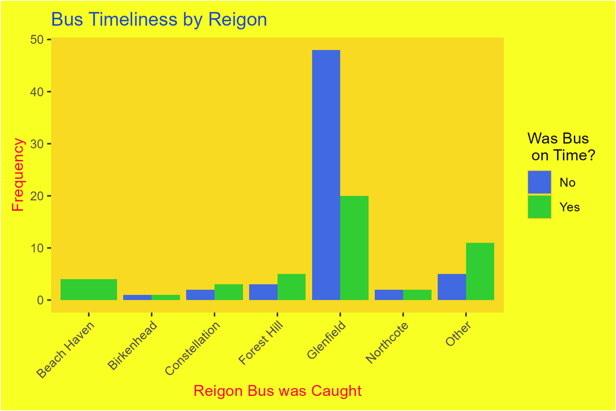

It seems like the most lateness of the bus occurred in the Glenfield region, as approximately 50 of the observed bus trips were late. Beach Haven did not have any lateness of the bus, as all of the buses caught in that region were on time.

## Average Delayedness Observed Across Regions

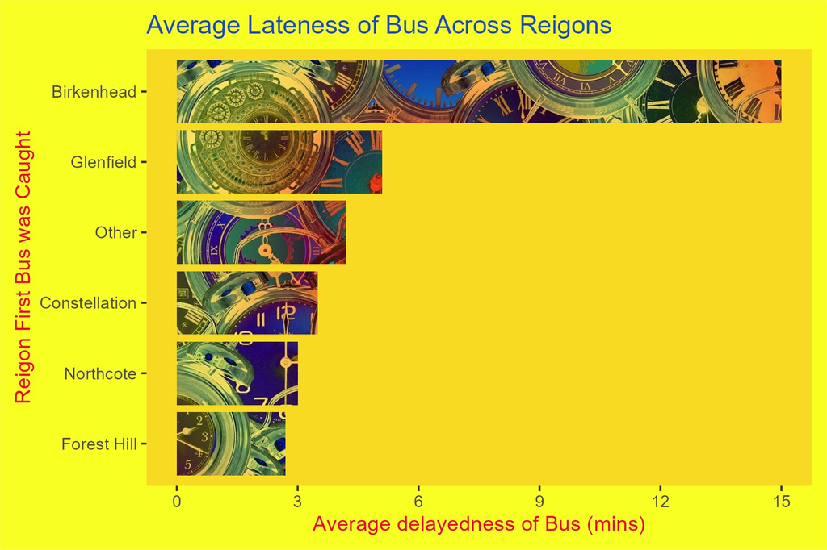

Mean Lateness of Bus Across Different regions

Birkenhead seems to have the most average bus lateness among the regions, with buses running approximately 15 minutes late on average. In contrast, Forest Hill experiences the shortest delays when buses are late, averaging just under 3 minutes. There is a significant difference of around 13 minutes between Birkenhead and the other areas in terms of average bus lateness. This could be due to the fact that only a very small number of buses were recorded as late in Birkenhead, and those few were significantly delayed. In comparison, Glenfield had a larger dataset on bus lateness, suggesting that its average is likely a more accurate representation of the true mean bus delay in that region.

**I wonder what the longest wait time for the late buses were for each of the regions?…**

## Longest Delay Oberserved Across Different Regions

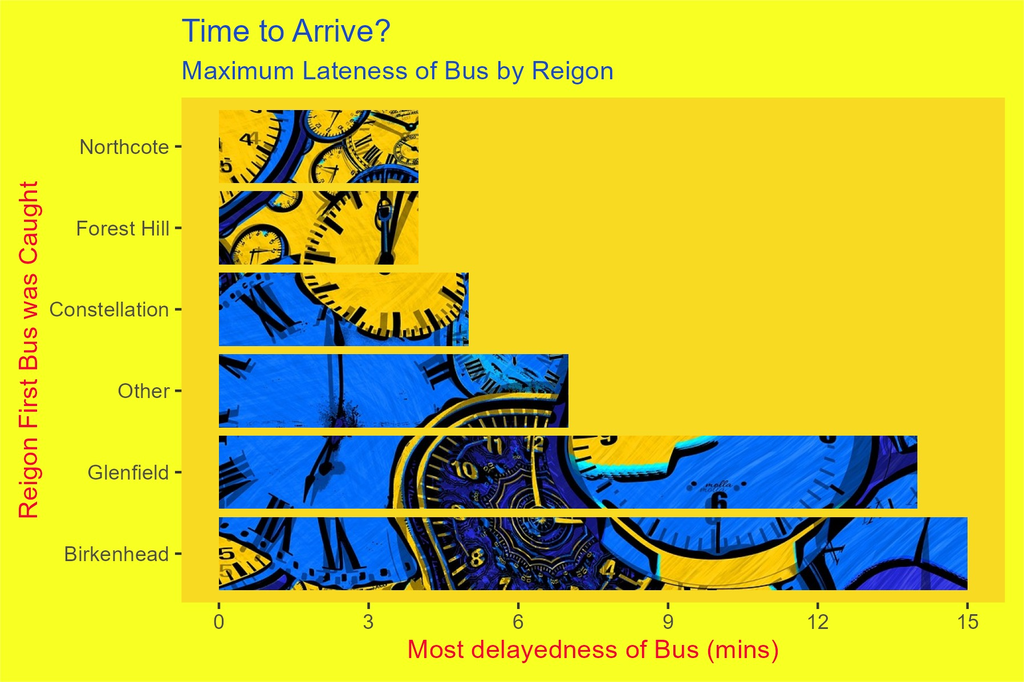

Maximum Lateness of the Bus acorss different regions

Both the Glenfield and Birkenhead regions had similar maximum wait times for late buses. In Birkenhead, the longest wait time was 15 minutes, while Glenfield followed closely behind with a wait time of 14 minutes. Northcote and Forest Hill had the shortest longest wait times, with buses never being more than 4 minutes late. Constellation and other regions had moderate maximum wait times of 5 and 7 minutes, respectively.

Despite the average wait time for late buses in Glenfield being around 5 minutes, the maximum wait time in that area was nearly as long as the average wait time for late buses in Birkenhead, which was 15 minutes.

[figure not shown]

**Now that we have looked at the bus lateness of the regions for the North Shore, I wonder what specific buses is most delayed?…**

## Bus Lateness per Tracked Buses

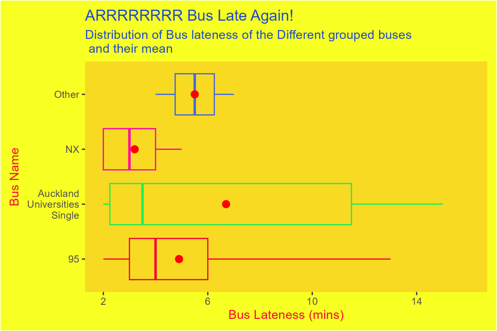

Bus Lateness of Different Buses Caught

*Note: The Auckland Universities Single stands for the buses caught not from the Northern Express routes that directly goes to Auckland Uni, such as the 939,931,933,923 (as in it stops by either UOA or AUT). The 95 is any of the 95 buses going to or coming from the city, so either 95B/C. NX is any of the Northern Express buses.*

Looking at the specific bus groups, the Auckland Universities Single buses stand out the most. These buses had the longest maximum wait times, with some delays reaching up to 15 minutes, which is just as bad as the worst delays we saw in Birkenhead earlier. On top of that, the average delay for these buses was also quite high, sitting around 7 minutes, suggesting that delays for this group were not only frequent but also longer than for most other buses.

The 95 buses also showed a fair bit of variation, with the longest delays stretching out to 13 minutes, but the average delay was a bit lower, at about 5 minutes. Their delays were more balanced overall, but still not great.

For the NX, Auckland Universities Single, and 95 buses, the average is higher than the typical wait time. This suggests that a few buses were extremely late, which pushed the average up. This was especially noticeable for the Auckland Universities Single buses, where delays varied a lot and the average was much higher than the middle of the data. It shows that some buses were much later than the rest. The 95 buses also had a similar pattern, though the difference was not as extreme. On the other hand, for NX and Other buses, the average and the typical delay were very close. This means their lateness was much more consistent and predictable.

**Now that we know about which regions and buses has the most delays in the bus arrivals, it would be interesting to know which hour of the day had the most frequent bus lateness?**

## Does the Hour of Day Effect the Lateness of Bus?

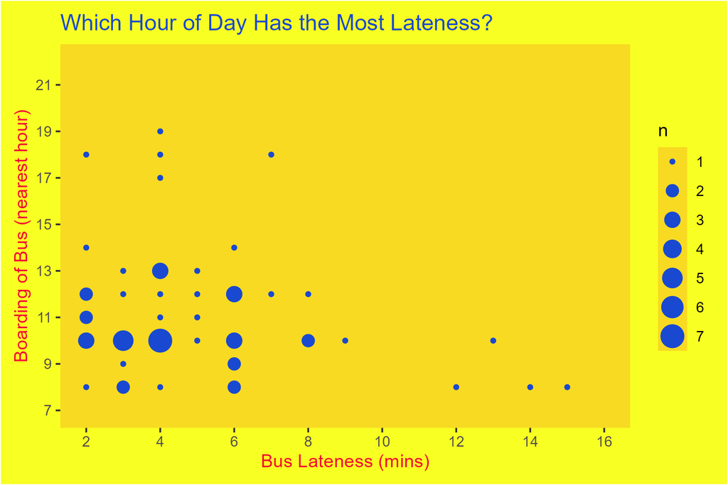

It looks like the most amount of bus delays occurred between 8am and 1pm. These hours have the largest number of late buses, as shown by the bigger blue bubbles. The bubbles represent how many late buses were recorded at each hour and level of lateness as the bigger the bubble, the more frequent the delays at that time.

**So what does this all mean?…**